# Replication package

# 1 Introduction

This document can be used to replicate the results from the manuscript on confounders. First, we provide a small example that serves as a simple case to build intuition. Second, we provide a larger example where we conduct a sensitivity analysis of unobserved/unknown confounders.

# 2 A first example to build intuition

## 2.1 The effect of a confounder

In our work we follow the notation of Pearl and claim that confounding is a purely causal concept (Pearl 2009). A confounder ($C$) is a variable that causally affects both the treatment ($X$) and the outcome ($Y$), and when a confounder exists we get a spurious (fake) association.

We need to distinguish between two types of studies common in software engineering: experiments (randomized controlled trial, RCT) and observational studies. One reason for why experiments are considered gold standard when conducting studies is that confounding is supposed to be, theoretically, a non-issue due to randomization (i.e., the effect of any confounders will be balanced out). So, very simply put, if we randomly allocate the treatment ($X$), then the causal effect of a confounder ($C$) on $X$ and $Y$ should not matter. With observational studies, on the other hand, the thought was for long that since the researcher did not control the environment a causal approach was impossible. We now know this is not true, and the Nobel Prizes of 2019 and 2021 are further indications of this.

If we look at it as software engineers, one possible way to visualize this would be to think about the impact of programming languages on code quality. Some people might assume that there’s a strong causal effect of language on quality. However, it’s not unreasonable to assume that a software engineer’s skills could have a direct causal effect on which programming language they use (e.g., skilled people use R) and on the final quality of the artefact produced (e.g., skilled people perform better no matter programming language).

A graphical summary (directed acyclic graph), of what we said above, can be visualized like this:

```r
my_dag <- dagify(
  Lang ~ Skills,
  Qual ~ Skills,
  Qual ~ Lang,
  exposure = "Lang", # treatment
  outcome = "Qual",
  coords = list(
    x = c(Lang = 1, Skills = 2, Qual = 3),
    y = c(Lang = 1, Skills = 2, Qual = 1)
  )
)

ggdag(my_dag) + theme_dag()
```

[output not shown]

In the plot above we see that the confounder, Skills, has a causal effect on the treatment, Lang, and on the outcome, Qual. Also, Lang has a direct causal effect on Qual, but that is what we’re generally speaking interested in estimating (i.e., treatment’s effect on the outcome).

Confounders are scary, but no need to panic. If we condition on a confounder (i.e., include it as a predictor in our model) we close the path $\overrightarrow{\mathrm{Lang} \leftarrow \mathrm{Skills} \rightarrow \mathrm{Qual}}$ and, hence, an unbiased estimate of the direct effect of Lang on Qual can be estimated. However, this means that we must have measured Skills, so we can condition on that variable. As we will see later, omitted variable bias (i.e., we do not have access to some variables) is something we can reason about and provide convincing arguments that it likely does not affect the results of a study. But how dangerous is omitted variable bias?

Let’s generate some fake data first. That way we *know* the truth.

```r
n <- 1e5
skills <- rnorm(n) # exogenous
lang <- 0.5 * skills + rnorm(n) # endogenous
# set language's effect on qual to 0.4
qual <- 0.3 * skills + 0.4 * lang + rnorm(n) # endogenous

d <- data.frame(
  skills = skills,
  lang = lang,
  qual = qual
)

# run two models, one where we don't condition on Skills, and one where we do
without_skills <- brm(
  qual ~ lang,
  data = d,
  refresh = 0
)

with_skills <- brm(
  qual ~ lang + skills,
  data = d,
  refresh = 0
)
```

Disregarding the estimate for our confounder, Skills (we’re seldom interested in the causal effect of a confounder, but there are exceptions), the estimates we have of Lang, i.e., $\widehat{\mathrm{Lang}}$, is what interests us.

```r
fixef(with_skills)[2, 1]
```

```
## [1] 0.3951058
```

```r
fixef(without_skills)[2, 1]
```

```
## [1] 0.5154114
```

Conditioning on Skills allows us to get the correct estimate for Lang ($\widehat{\mathrm{Lang}}_s \approx$ 0.4) since we close the backdoor. If we don’t condition on Skills we get a biased (in this case positive) estimate, i.e., $\widehat{\mathrm{Lang}}_{\neg s} \approx$ 0.52, because of Skills’s effect on both Lang and Qual.

There are a few lessons to learn from the above simple example. First, confounders can have an effect on the estimate. Second, the bias is positive in this case, but can also be negative (change Skills’s sign on Lang and you’ll see). Third, if we want to have an unbiased estimate we need to condition on the confounder (Skills in this case), to close the backdoor that goes from $\overrightarrow{\mathrm{Lang} \leftarrow \mathrm{Skills} \rightarrow \mathrm{Qual}}$.

If we conduct an obervational study, and if we don’t have access to Skills, i.e., it’s unmeasured for some reason, or perhaps unknown, then we are now facing omitted variable bias. However, all is not lost. *We can still argue if it’s likely that Skills would nullify the causal effect of Lang on Qual*.

## 2.2 Accounting for the unknown[^1]

If we look at the DAG we introduced previously,

we see that there are two arrows going from Skills. First, we have $\mathrm{Skills} \rightarrow \mathrm{Lang}$ and then we have $\mathrm{Skills} \rightarrow \mathrm{Qual}$. These two edges are dependent on each other. If we want to assess the effect of Skills on Lang, one often talks about the Scaled Mean Difference (SMD).

The SMD is the confounder’s effect on the different groups in Lang (e.g., Java and Python). In math, it’s something like this:

$$\mathrm{SMD} =
\frac{\overline{\mathrm{Skills}}_{\mathrm{Java}} -
\overline{\mathrm{Skills}}_{\mathrm{Python}}}{\sigma_Z}$$

The difference in mean between Java and Python can then, by using SMD, be represented as a difference in $\sigma$. For example, a $3\sigma$, $1\sigma$, or $0.1\sigma$ difference between two categories.

If we next look at the other arrow ($\mathrm{Skills} \rightarrow \mathrm{Qual}$), we don’t need to think about the SMD since Skills is affecting the outcome Qual and not the treatment Lang. Here we can simply estimate the effect as a regular $\beta$ estimate that we’re used to, i.e., in our case the $\beta_{\mathrm{Skills}}$ estimate of our confounder Skills. As is common, one could for example say that $\beta_{\mathrm{Skills}} = 3$ meaning that a 1-unit change in Skills would imply a 3-unit change in Qual.

With these two concepts, the SMD and the $\beta_{\mathrm{Skills}}$ estimate, we can now add assumptions to our analysis and argue how likely it is that they would hold. According to Lin, Psaty, and Kronmal (1998) we now have three options to choose between:

- Make assumptions concerning $\beta_{\mathrm{Skills}}$, and estimate how large SMD needs to be to cancel out the direct effect of Lang on Qual.
- Make assumptions concerning SMD, and estimate how large $\beta_{\mathrm{Skills}}$ needs to be to cancel out the direct effect of Lang on Qual.
- Finally, by specifying both SMD and $\beta_{\mathrm{Skills}}$ we can investigate the number and size of confounders, $n_c$, needed to cancel out the direct effect of Lang on Qual.

We will focus on the first two analyses, since they are more common.

### 2.2.1 Assumptions concerning $\beta_{\mathrm{Skills}}$

If we continue with the example, we can collect the true effect’s lower confidence interval ($\approx 0.4$) and assume $\beta_{\mathrm{Skills}} = 1.5$, i.e., a 1-unit change in Skills would imply a 1.5-unit change in Qual:

```r
tidy(with_skills, conf.int = TRUE) |>
  filter(term == "lang") |>
  pull(conf.low) |>
  tip(confounder_outcome_effect = 1.5)
```

```
## The observed effect (0.39) WOULD be tipped by 1 unmeasured confounder
## with the following specifications:
##   * estimated difference in scaled means between the unmeasured confounder
##     in the exposed population and unexposed population: -2.33
##   * estimated relationship between the unmeasured confounder and the outcome: 1.5
```

```
## # A tibble: 1 × 5
##   effect_adjusted effect_observed exposure_confounder_e…¹ confounder_outcome_e…²
## *           <dbl>           <dbl>                   <dbl>                  <dbl>
## 1               1           0.389                   -2.33                    1.5
## # ℹ abbreviated names: ¹exposure_confounder_effect, ²confounder_outcome_effect
## # ℹ 1 more variable: n_unmeasured_confounders <dbl>
```

then a hypothetical unmeasured continuous confounder with $\beta_{\mathrm{Skills}} = 1.5$ and $\mathrm{SMD} \approx -2.3$, would cancel out the effect (in our case $0.4$) of Lang on Qual. Hence, given our assumptions, a 1-unit change in an unmeasured confounder (Skills) leading to a 1.5-unit change in Qual and, *et voilà*, you would not have a Nature paper. Visualizing what this means might help.

Assume that the Skills is some latent variable we have to measure such a construct. Assume we have som quality measure we’re interested in distributed as $\mathrm{Normal}(45,1.5)$. Our scaled difference that we received above (i.e., $-2.3$) can be transformed to a quality score by multiplying with $\sigma = 1.5$ (our assumed dispersion), i.e., $1.5 \cdot -2.3 \approx -3.45$. This implies that between two categories (Java and Python) we would need to see a difference of approximately $3.45$ in a quality score when implementing a feature. Is this unlikely? Perhaps; context matters.

However, as an empirical researcher you might not want to bet your life on it if you look at the plot below; this is how large a difference there would be between the two languages. More importantly, you should present these results to your readers and argue for why it is either a) unlikely that a counfounder exists, or b) go measure the latent variable Skills carefully.

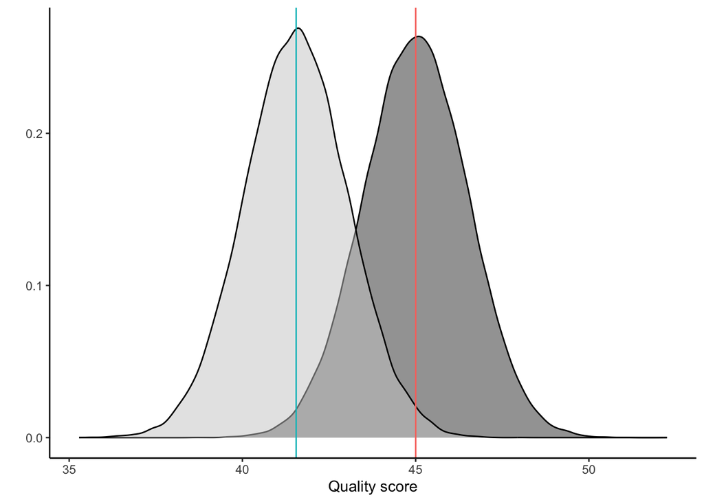

### 2.2.2 Assumptions concerning SMD

As previously explained, there are two arrows going from Skills. In the previous section we focused on the arrow $\mathrm{Skills} \rightarrow \mathrm{Qual}$, i.e., setting the $\beta_{\mathrm{Skills}}$ estimate to analyze the size of SMD needed to cancel out the direct causal effect of Lang on Qual. Here we will now do the opposite, i.e., given an SMD, how large a $\beta_{\mathrm{Skills}}$ is needed to cancel out the causal effect of $Lang \rightarrow Qual$.

For the sake of completness we’ll assume $\mathrm{SMD} = -2.3$ to validate the result in the previous section, i.e., we should end up with $\beta_{\mathrm{Skills}} \approx 1.5$.

```r
tidy(with_skills, conf.int = TRUE) |>
  filter(term == "lang") |>
  pull(conf.low) |>
  tip(exposure_confounder_effect = -2.3)
```

```
## The observed effect (0.39) WOULD be tipped by 1 unmeasured confounder
## with the following specifications:
##   * estimated difference in scaled means between the unmeasured confounder
##     in the exposed population and unexposed population: -2.3
##   * estimated relationship between the unmeasured confounder and the outcome: 1.51
```

```
## # A tibble: 1 × 5
##   effect_adjusted effect_observed exposure_confounder_e…¹ confounder_outcome_e…²
## *           <dbl>           <dbl>                   <dbl>                  <dbl>
## 1               1           0.389                    -2.3                   1.51
## # ℹ abbreviated names: ¹exposure_confounder_effect, ²confounder_outcome_effect
## # ℹ 1 more variable: n_unmeasured_confounders <dbl>
```

Above we see that $\beta_{\mathrm{Skills}} \approx 1.50$ (i.e., the confounder_outome_effect), thus we have an indication that this works both ways. Given that we have introduced two distinct concepts used to estimate unobserved/unknown confounders, we can now turn our attention to a more involved example.

# 3 A second, more involved, example

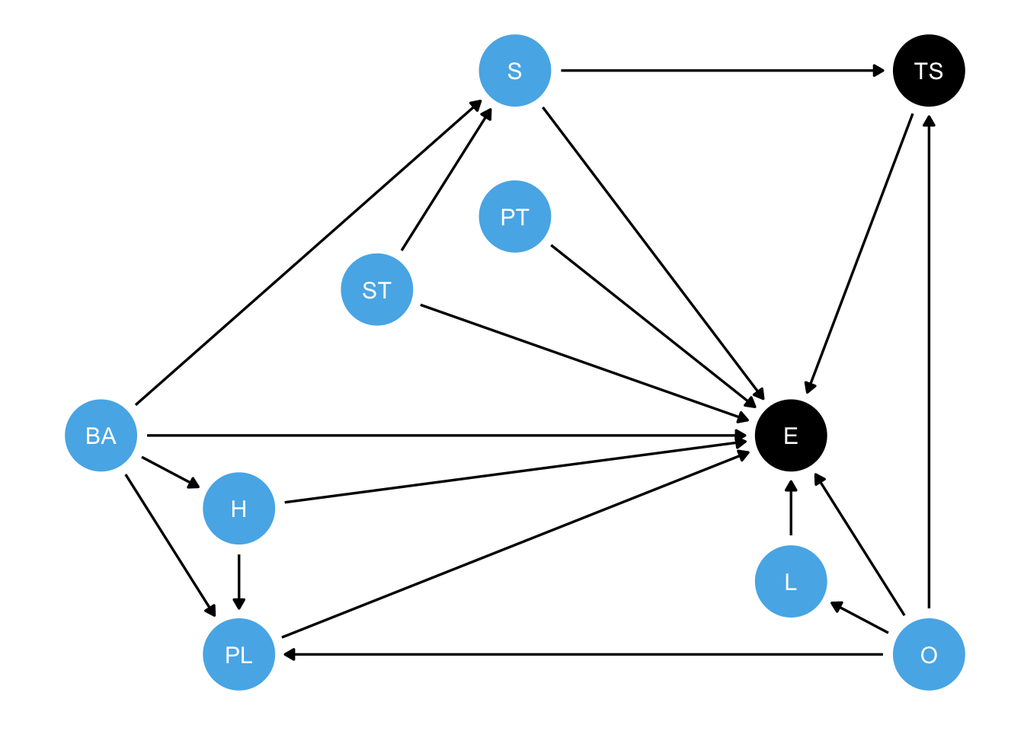

Feldt et al. (2023) extracted causal links from several primary studies and attempted to assemble disparate evidence into a Unified Directed Acyclic Graph (UDAG) as above. In the UDAG above the letters are, from left to right, short for: $BA$ Business Area, $PL$ Programming Language, $H$ Hardware, $ST$ Software Type, $PT$ Project Type, $S$ Size of software, $L$ Location, $E$ Effort, $O$ Organization type, and $TS$ Team Size.

We’d like to know the direct effect of $TS$ on $E$ (both in black), i.e., Team Size’s direct effect on Effort. One would think it’s a straightforward thing to measure, but not taking into account confounders would lead to biased estimates, i.e., spurious associations.

The UDAG, as we will see, will also help us understand if a sensitivity analysis of unknown confounders is needed. In short, it would allow a future study to either be more sure of not facing omitted variable bias from start, i.e., the UDAG is likely correct, or force us to collect variables that are currently unmeasured, i.e., the UDAG needs to be complemented with new variables.

The above UDAG is clearly a more involved example and contains all elemental constructs one can find in a DAG, e.g., Organization ($O$) is a confounder, Hardware ($H$) is part of a pipe since $BA \rightarrow H \rightarrow E$, and the lower part also contains an ancestors of the outcome, e.g., $L$. Additionally, we also see that there are colliders (e.g., $PL$) in the UDAG. Let’s see what we should condition on by calculating the adjustment set for the UDAG:

```r
adjustmentSets(udag, effect = "direct")
```

```
## { O, S }
```

The adjustment set is $\mathcal{A} = \{ O, S \}$. By conditioning on $O$ and $S$ (i.e., adjusting for $O$ and $S$) we will be able to estimate the direct effect of $TS$ on $E$. But what if there are unknown confounders? It’s not unlikely given that the studies that contributed to the UDAG are all observational.

Let’s do this systematically and overlay numbers on the plot, from bottom to top, to make sure that we don’t miss anything.

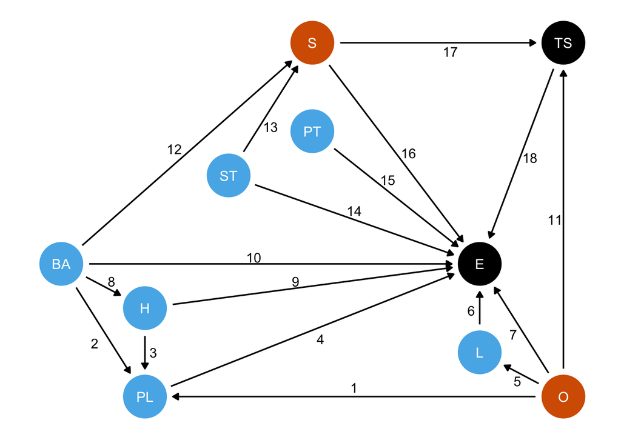

In the plot above we have the treatment and outcome in black, as before, but we have now also added the color orange to signify that these are variables we condition on.

If we look at the plot above, and take Edge #1 as an example, the question we’re asking is:

> If there would be a confounder $C$ between $PL$ and $O$, i.e. $PL \leftarrow C \rightarrow O$, (in addition to the existing edge $PL \leftarrow O$), how would that affect our possibility to estimate the direct effect of $TS$ on $E$, given our adjustment set $\mathcal{A}$?

The potential answer to the above question would be one of three cases:

1. It would not affect the estimate (**n/a**).
2. By conditioning on other variable(s) we close the path and then the confounder will not affect the estimate (**co**).
3. We truly have a case of omitted variable bias, which means that we need to conduct a sensitivity analysis (**ovb**).

In Case 1 (**n/a**), a confounder would not affect the possibility for us to receive an unbiased causal estimate of the direct effect. In Case 2 (**co**), the confounder would affect our possibility to get an unbiased estimate; however, if we condition on $1,\ldots,n$ other variables, the confounder would no longer affect the results and, thus, fall under the **n/a** category. Finally, Case 3 (**ovb**), is the one we are terrified about. Here a potential confounder would affect our possibility to get an unbiased estimate. This means that we either need to add additional assumptions and argue that this confounder is unlikely to exist, or think harder, identify such a confounder, and then measure it carefully.

If we next analyze what it would imply if an unknown confounder truly existed at each of the above edges, while we condition on $S$ and $O$, we quickly see that there are only two edges that we need to be careful about: Edges #17 and #18.

Below is an updated UDAG where we mark all variables that we condition on in orange, the confounder is in yellow, while the outcome and treatment are in black. Other variables that we have no use for are now removed from the plot and futher analysis.

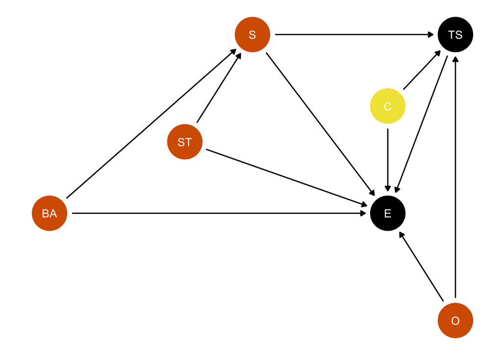

Evidently, we see that we condition on more variables than $S$ and $O$ (which was declared as the *minimal* adjustment set). We also included $BA$ and $ST$ because we wanted to close backdoor paths to avoid any unmeasured or unknown confounders.

How did we come to the results above? Well, analyzing the UDAG according to causal calculus (Pearl 2009) leads to the above results and with experience one receives intuition when analyzing DAGs. However, one can (should) also use software to get some assistance, e.g., the [dagitty](https://dagitty.net) package in R. If you are so inclined you can verify [online](http://dagitty.net/mLQZroN) that our analysis above is correct.

To summarize, we have a challenge dealing with a confounder $C$, which affects both our treatment $TS$ and the outcome $E$, i.e., $TS \leftarrow C \rightarrow E$. Perhaps a researcher could swear that such a confounder cannot physically exist for the studied phenomena, but if one is not 100% sure, then we should do better and fall back on sensitivity analysis of unknown confounders.

## 3.1 Sensitivity analysis of unknown confounders

In addition to the outcome $E$ and the treatment $TS$, there are several variables we’ve decided to control (adjust) for, i.e., $\mathcal{A} = \{ S, O, ST, BA \}$ (the latter two so that any confounder between $S$ and $TS$ is cancelled out).

The case we have in front of us is the classical case of a confounder affecting both the treatment and the outcome.

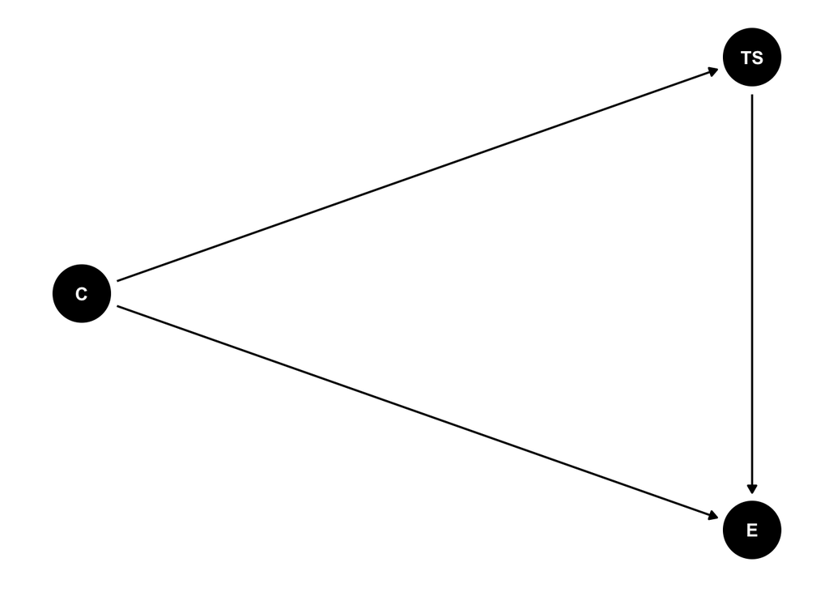

First, we need to decide on any assumptions concerning the direct effect of $TS$ on $E$. Next, we need to ascertain the effect a confounder must have on $TS$ and $E$ to cancel out that effect (i.e., to make it cross zero according to some credible interval).

In summary the characteristics of the three variables of interest are:

- Team Size ($TS$), treatment: $\mathbb{N}^+$, a natural positive number indicating number of members in a team.
- Effort ($E$), outcome: $\mathbb{N}^+$, a natural positive number indicating hours spent in a project.
- Confounder ($C$): Assume $\mathbb{R}$, i.e., a $\mathsf{Normal}$ distribution.

Let’s design a generative model according to the above.

```r
# This part only sets up our stat model so we can execute it in the sim()

# Set initial effects
# Confounder's effect on TS; vary this too c(-1.0, -0.5, 0.0, 0.5, 1.0)
b_cts <- 1.0
# Confounder's effect on outcome; vary this too c(-1.0, -0.5, 0.0, 0.5, 1.0)
b_c <- 1.3
# TS's effect on outcome; vary this too (-0.5, -0.25, -0.1, 0.1, 0.25, 0.5)
b_ts <- 0.1

c <- rnorm(100)
ts <- rpois(100, 5 + b_cts * c)
e <- rnorm(100, b_c * c + b_ts * ts)
df <- data.frame(C = c, TS = ts, E = e)

# Set weakly informative priors
# N(0,2) prior on intercept; still allows for absurd, ⍺ = {-5,5}, effects
# N(0,1) prior on β est; still allows for absurd, β = {-3,3}, effects
# Exponential(1) on σ; still allows for absurd, σ = 5, effects
# Run once so we can reuse model in sim
m <- brm(E ~ C + TS, data = df, refresh = 0,
  prior = c(prior(normal(0, 1), class = b),
            prior(normal(0, 2), class = Intercept),
            prior(exponential(1), class = sigma))
)
```

```r
# Set up and run simulation

# Sample sizes for the rand() functions
n <- seq(10, 100, 5)

# number of sim runs; thank you CLT...
n_sim <- 200

# For β_ts we need to consider an effect size. Generally, for a coefficient β,
# effect sizes between 0.10–0.29 are said to be small, effect sizes between
# 0.30–0.49 are medium, and effect sizes of 0.50 or greater are large. YMMV
#
# Cohen, J. Statistical Power Analysis for the Behavioral Sciences, 2nd ed.;
# Erlbaum: Hillsdale, MI, USA, 1988; ISBN 0-8058-0283-5.
# Fey, C.F.; Hu, T.; Delios, A. The Measurement and Communication of Effect
# Sizes in Management Research. Manag. Organ. Rev. 2022, 1–22.

# 96 effect combinations
g <- expand.grid(c(-1.0, -0.5, 0.5, 1.0), # β_cts
                 c(-1.0, -0.5, 0.5, 1.0), # β_c
                 c(-0.5, -0.3, -0.1, 0.1, 0.3, 0.5)) # β_ts!

registerDoParallel(detectCores() - 1)

res <- sim(n, n_sim, g)

stopImplicitCluster()
```

# References

Feldt, R., M. Shepperd, C. A. Furia, and R. Torkar. 2023. “Causal Systematic Reviews—Synthesizing Scientific Knowledge Through Causal Links.” *arXiv*.

Lin, D. Y., B. M. Psaty, and R. A. Kronmal. 1998. “Assessing the Sensitivity of Regression Results to Unmeasured Confounders in Observational Studies.” *Biometrics* 54 (3): 948–63.

Pearl, J. 2009. *Causality: Models, Reasoning and Inference*. 2nd ed. Cambridge University Press.

[^1]: A more involved example can be found at https://evalf21.classes.andrewheiss.com/example/confounding-sensitivity/#you-can-never-close-every-backdoor-without-an-experiment